# Question 4 - Logistic regression analysis

### Crosstable predicted and observed responses

```r
mydata$Purchasedpred[fitted(model4) <=0.5] <- 0
mydata$Purchasedpred[fitted(model4) > 0.5] <- 1
mydata$Purchasedpred<-factor(mydata$Purchasedpred, levels = c(0:1), labels = c("No","Yes"))
CrossTable(mydata$Purchasedpred, mydata$Purchased, prop.r=FALSE, prop.c = FALSE,
           prop.t = FALSE,
           prop.chisq=FALSE, format = "SPSS",
           fisher = FALSE, chisq = TRUE,
           expected = FALSE, sresid = FALSE)
```

```
   Cell Contents
|-------------------------|
|                   Count |
|-------------------------|

Total Observations in Table:  359

                     | mydata$Purchased
mydata$Purchasedpred |       No  |      Yes  | Row Total |
---------------------|-----------|-----------|-----------|
                  No |      212  |       39  |      251  |
---------------------|-----------|-----------|-----------|
                 Yes |       19  |       89  |      108  |
---------------------|-----------|-----------|-----------|
        Column Total |      231  |      128  |      359  |
---------------------|-----------|-----------|-----------|


Statistics for All Table Factors


Pearson's Chi-squared test
------------------------------------------------------------
Chi^2 =  147.1726     d.f. =  1     p =  7.194579e-34

Pearson's Chi-squared test with Yates' continuity correction
------------------------------------------------------------
Chi^2 =  144.2723     d.f. =  1     p =  3.09783e-33


       Minimum expected frequency: 38.50696
```

From this confusion matrix, we can see we made 19 type 1 errors or false positives and 39 type 2 errors or false negatives. Therefore our model is worse at predicting when an actual purchase has been made.

The overall accuracy of our model is 83.84%.

### Odds Ratios

```r
exp(model4$coefficients)
```

```
    (Intercept)             Age EstimatedSalary
      0.3202232       1.2517688       1.0000344
```

Based on the results shown above we can say that on average the odds of a person making a purchase is 0.32, and these odds are 1.25 times higher based on a unit increase in age whereas it increases very little based on unit increase in estimated salary by about 1.0000344 times the intercept value.

```r
pander(exp(confint(model4)),
       caption = "95% confidence interval of odds ratio")
```

```
---------------------------------------
       &nbsp;          2.5 %    97.5 %
--------------------- -------- --------
   **(Intercept)**     0.2229   0.4472

       **Age**         1.194    1.324

 **EstimatedSalary**     1        1
---------------------------------------

Table: 95% confidence interval of odds ratio
```

From the results shown above, we see that the confidence intervals are small for both our predictor variables indicating that the estimates are reliable with little random error.

### Examing Assumptions

First we test the multi-collinearity assumption of our model.

```r
1/vif(model4)
```

```
            Age EstimatedSalary
       0.757185        0.757185
```

We can see that the tolerance values are larger that 0.2 and so there is no indication of collinearity.

Secondly, we test if the errors are indeed independent.

```r
durbinWatsonTest(model4)
```

```
 lag Autocorrelation D-W Statistic p-value
   1      0.04995433      1.895589   0.296
 Alternative hypothesis: rho != 0
```

Lastly, we wanted to check if there was some kind of linearity between the log odds and our independent variables.

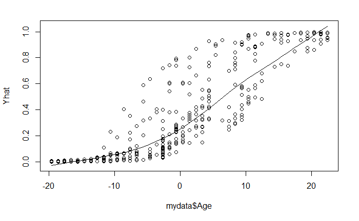

```r
Yhat    <- fitted(model4)
scatter.smooth(mydata$Age,Yhat)
```

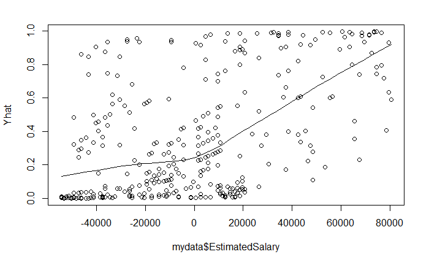

```r
scatter.smooth(mydata$EstimatedSalary,Yhat)
```

### Pseudo R squared Value

```r
logisticPseudoR2s <- function(LogModel) {

        dev <- LogModel$deviance

        nullDev <- LogModel$null.deviance

        modelN <-  length(LogModel$fitted.values)

        R.l <-  1 -  dev / nullDev

        R.cs <- 1- exp ( -(nullDev - dev) / modelN)

        R.n <- R.cs / ( 1 - ( exp (-(nullDev / modelN))))

        cat("Pseudo R^2 for logistic regression\n")

        cat("Hosmer and Lemeshow R^2  ", round(R.l, 3), "\n")

        cat("Cox and Snell R^2        ", round(R.cs, 3), "\n")

        cat("Nagelkerke R^2           ", round(R.n, 3),    "\n")

}

logisticPseudoR2s(model4)
```

```
Pseudo R^2 for logistic regression
Hosmer and Lemeshow R^2   0.457
Cox and Snell R^2         0.449
Nagelkerke R^2            0.617
```

Here we present the pseudo R squared values for our model. The pseudo R square value is between 0 and 1 and gives an indication for how well our model can explain the data or how good our model fit is. It’s a useful metric to compare different models.

### Impact Analysis of Individual Cases.

```r
mydata$leverage<-hatvalues(model4)
mydata$stud.res<-rstudent(model4)
mydata$dfbeta<-dfbeta(model4)
troublingdata<-subset(mydata, (leverage > 3*.0083) | (abs(stud.res) > 2),
       select = c("leverage", "stud.res", "dfbeta"))
head(troublingdata)
```

|  | leverage | stud.res | dfbeta |
| --- | --- | --- | --- |
| 6 | 0.038851272 | 1.0403880 |  |
| 28 | 0.026692529 | 1.7393315 |  |
| 43 | 0.028350879 | 1.4587209 |  |
| 57 | 0.004615143 | -2.9270389 |  |
| 94 | 0.036410995 | 0.9637591 |  |
| 135 | 0.007650423 | 2.3399829 |  |

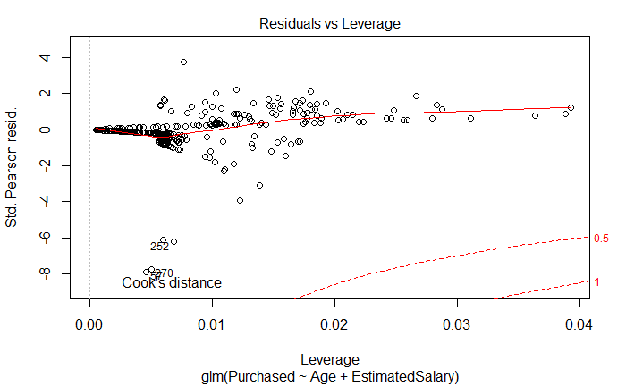

```r
plot(model4, which=5)
```

We have also looked into the impact of individual cases as well by looking at the studentized residuals, the leverage values and the dfbeta values. We have calculated the leverage as 1+(# of predictors)/# of observations. We check for values greater than 3 times the average leverage and for values with the absolute studentized residuals greater than 2. In addition we also looked for points outside the dashed red line in the plot of the residuals vs leverage to see if there were points with a large cook’s distance as well. We have removed some of these points and noticed an improvement in the pseudo R squared values as well. Infact for this analysis we have used the cleaned dataset after removing values with high leverage based on the previous one as can be seen in the name of the file used too.